# Projekt 2

Laszczyk Jakub, Trojszczak Oliwia

2022-11-18

## Wstep

Każdego dnia na świecie umiera około 153,5 tys. osób, czyli około 56 mln osób rocznie. Istnieje wiele przyczyn śmiertelności ludzi. Jedną z głównych przyczyn zgonów na świecie są choroby sercowo-naczyniowe i jak podaje WHO stanowią one obecnie 16% przyczyn wszystkich zgonów. Co około 3 osoba umiera z powodu problemów z sercem.

Do naszego projketu użyliśmy danych pochodzących ze strony Zbiór danych pochodzi ze strony https://www.kaggle.com/datasets/andrewmvd/heart-failure-clinical-data. Celem projektu jest przewidywanie śmiertelności z powodu niewydolności serca. Do tego użyto lacznie 12 zmiennych opisanych poniżej:

## Opis danych

- age - wiek pacjenta
- anaemia - czy liczba czerwonych krwinek lub hemoglobiny się zmniejszyła (0 = Nie, 1 = Tak)
- creatinine_phosphokinase - Poziom enzymu CPK we krwi (mcg/l)
- diabetes - czy pacjent ma cukrzyce czy nie (0 = Nie, 1 = Tak)
- ejection_fraction - Procent krwi ubywający z serca przy każdym skurczu
- high_blood_pressure - Jeśli pacjent ma nadciśnienie (0 = Nie, 1 = Tak)
- platelets - Płytki krwi (kilopłytki/ml)
- serum_creatinine - Stężenie kreatyniny we krwi w surowicy (mg/dl)
- serum_sodium - Stężenie sodu w surowicy krwi (mEq/L)
- sex - plec (Mezczyzna = 1, Kobieta =0)
- smoking - czy pacjent pali czy nie (0 = Nie, 1 = Tak)
- death_event - Jeśli pacjent zmarł w okresie obserwacji (0 = Nie, 1 = Tak)

#Podstawowe statystyki opisowe

```
##                          vars   n      mean       sd   median   trimmed
## age                         1 299     60.83    11.89     60.0     60.22
## anaemia                     2 299      0.43     0.50      0.0      0.41
## creatinine_phosphokinase    3 299    581.84   970.29    250.0    365.49
## diabetes                    4 299      0.42     0.49      0.0      0.40
## ejection_fraction           5 299     38.08    11.83     38.0     37.43
## high_blood_pressure         6 299      0.35     0.48      0.0      0.32
## platelets                   7 299 263358.03 97804.24 262000.0 256730.09
## serum_creatinine            8 299      1.39     1.03      1.1      1.19
## serum_sodium                9 299    136.63     4.41    137.0    136.82
## sex                        10 299      0.65     0.48      1.0      0.68
## smoking                    11 299      0.32     0.47      0.0      0.28
##                               mad     min      max    range  skew kurtosis
## age                         14.83    40.0     95.0     55.0  0.42    -0.22
## anaemia                      0.00     0.0      1.0      1.0  0.28    -1.93
## creatinine_phosphokinase   269.83    23.0   7861.0   7838.0  4.42    24.53
## diabetes                     0.00     0.0      1.0      1.0  0.33    -1.90
## ejection_fraction           11.86    14.0     80.0     66.0  0.55     0.00
## high_blood_pressure          0.00     0.0      1.0      1.0  0.62    -1.62
## platelets                65234.40 25100.0 850000.0 824900.0  1.45     6.03
## serum_creatinine             0.30     0.5      9.4      8.9  4.41    25.19
## serum_sodium                 4.45   113.0    148.0     35.0 -1.04     3.98
## sex                          0.00     0.0      1.0      1.0 -0.62    -1.62
## smoking                      0.00     0.0      1.0      1.0  0.76    -1.42
##                               se
## age                         0.69
## anaemia                     0.03
## creatinine_phosphokinase   56.11
## diabetes                    0.03
## ejection_fraction           0.68
## high_blood_pressure         0.03
## platelets                5656.17
## serum_creatinine            0.06
## serum_sodium                0.26
## sex                         0.03
## smoking                     0.03
```

## Wykresy

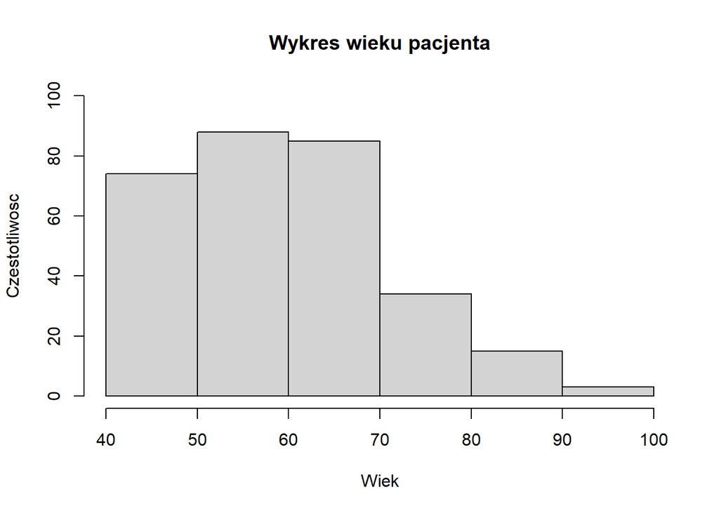

Pierwszy wykres typu histogram przedstawia wiek badanych osob. Mozna zauwazyc, ze wiekszosc pacjentow jest w wieku 40-70, znaczna mniejszosc to osoby powyzej 70 roku zycia.

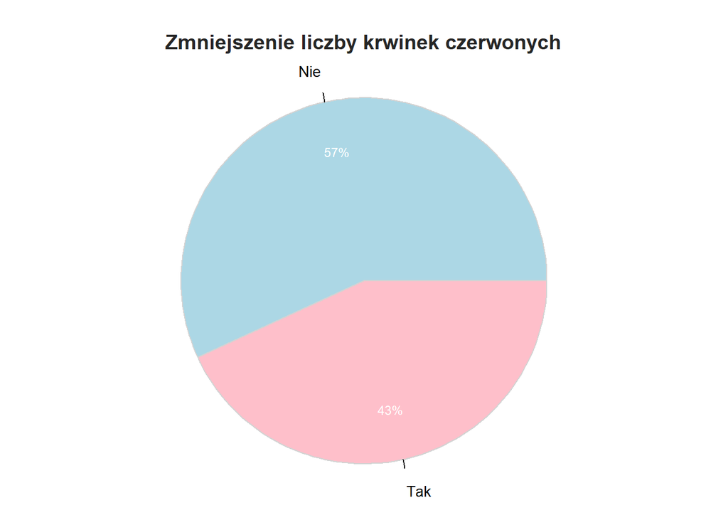

Na powyzszym wykresie mozemy zaobserwowac, czy liczba badanych krwinek czerwonych u pacjenta zmniejszyla sie, czy tez nie. W przypadku 43% badanych osob, liczba krwinek spadla.

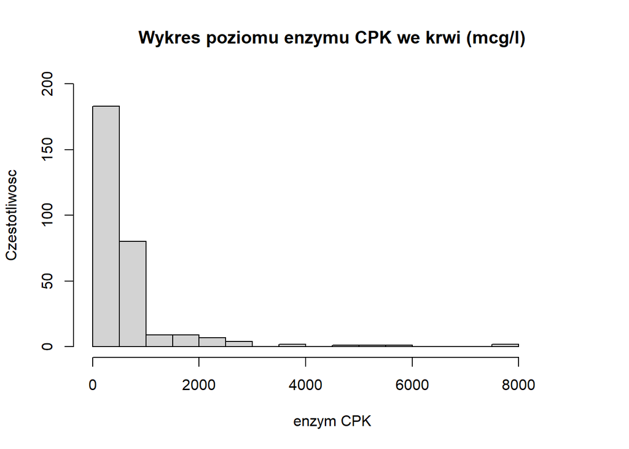

Wykres ukazuje poziom enzymu CPK we krwi w przelizeniu na mcg/l. W przypadku około 60% osob, ilosc tego enzymu we krwi wacha sie w przedziale od 0 do 500 mcg/l. Okolo 25% wykryto poziom CPK na poziomie od 500 do 1000 mcg/l. Zdecydowana mniejszosc badanych posiada poziom tego enzymu na poziomie wiekszym niz 1000 mcg/l, a skrajne przypadki dochodza nawet do 8000 mcg/l.

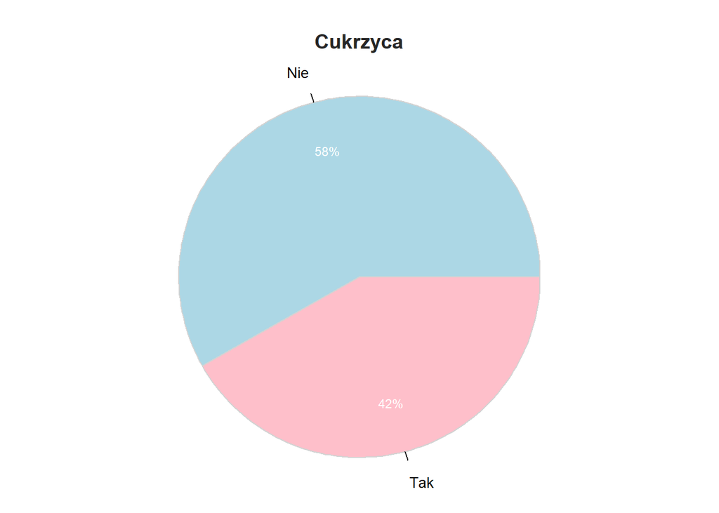

Powyzszy wykres przedstawia wystepowanie lub nie cukrzycy u pacjenta. W przypadku 58% badanych pacjentow, cukrzyca nie wystepuje, w pozostalych 42% wystepuje.

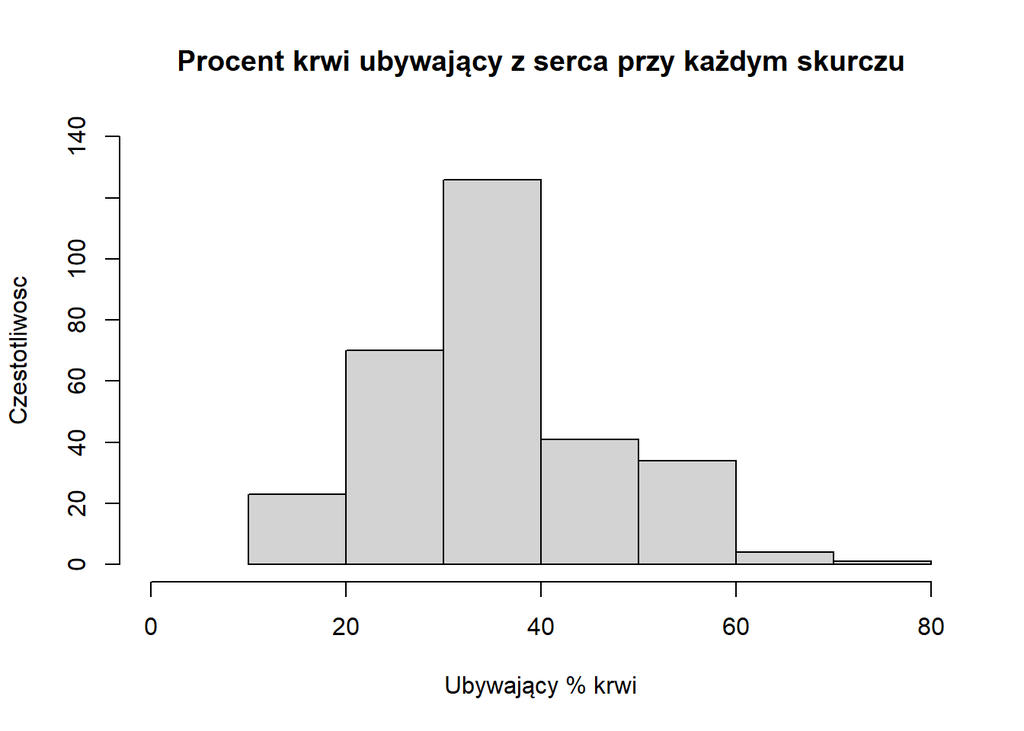

Kolejny wykres przedstawia w jakim % krew ubywa z serca w przypadku skurczu. W wiekszosci przypadkow jest to okolo 30-40% krwi. W przypadku ponad 70% badanych ubywajacy % krwi z serca nie przekracza 40%. Jak mozna zauwazyc jest tez przypadek, gdzie przy takim skurczu osoba traci 70-80% krwi z serca.

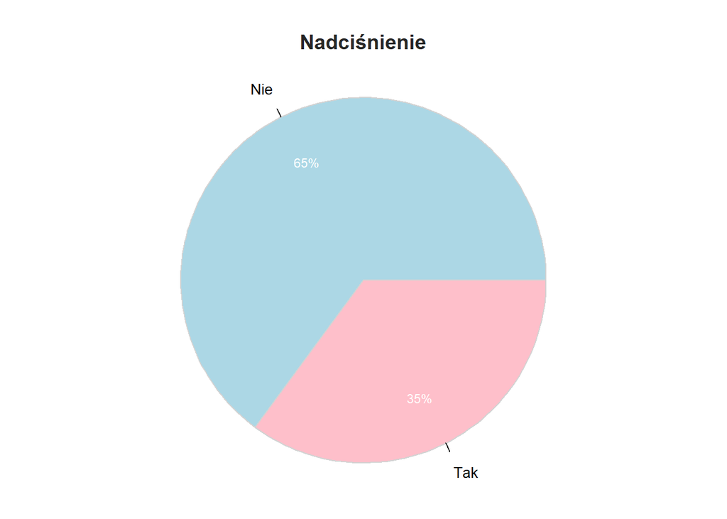

Powyzszy wykres kolowy pokazuje czy u pacjenta zanotowano nadcisnienie. Jak latwo zauwazyc, u prawie 2/3 badanych (65%) nie wystepuje nadciśnienie. Zmaga sie z nim 35% osob badanych.

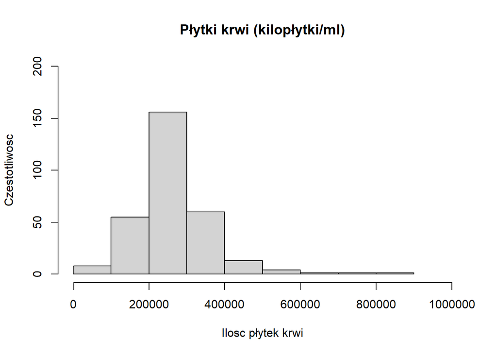

Kolejny wykres przedstawia ilosc plyrek krwi wyrazonych w kiloplytkach/ml. Najwiecej przypadkow (ponad 50%) nalezy do przedzialu od 200000 do 300000 kiloplytek/ml. Zdycydowanie ponad 75% miesci sie w przedziale 100000 do 400000 kiloplytek/ml.

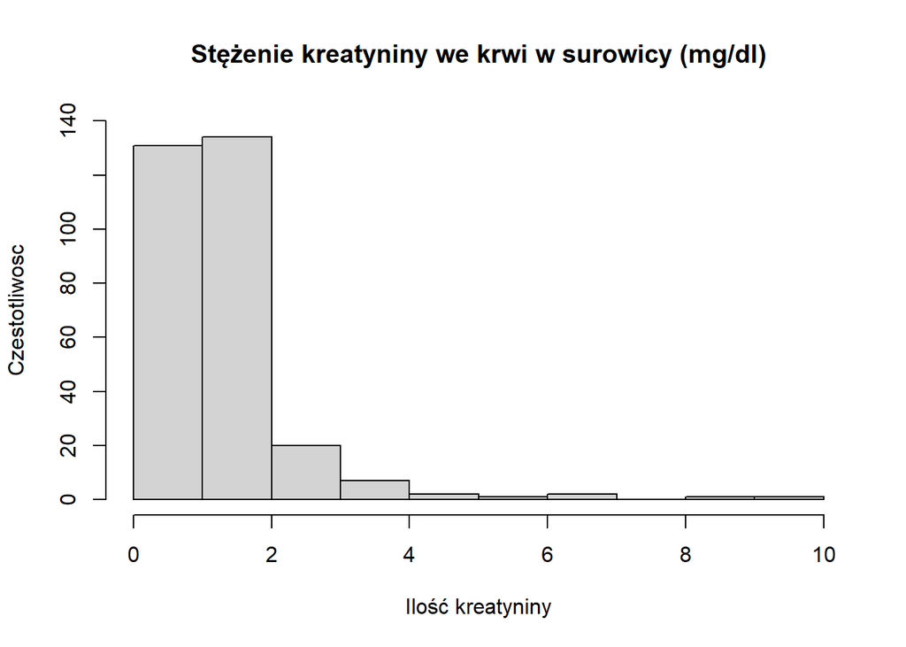

Patrzac na wykres stezenia kreatyniny we krwi w surowicy wyrazonych w mg/dl, zdecydowana wiekszosc, bo ponad 80% danych znjaduje sie w przedziale od 0 do 2 mg/dl. Sa to osoby z prawidlowym stezeniem, gdyz norma wynosi tutaj 0,6-1,3 mg/dl. Reszta przebadanych osob posiada jej nadmiar.

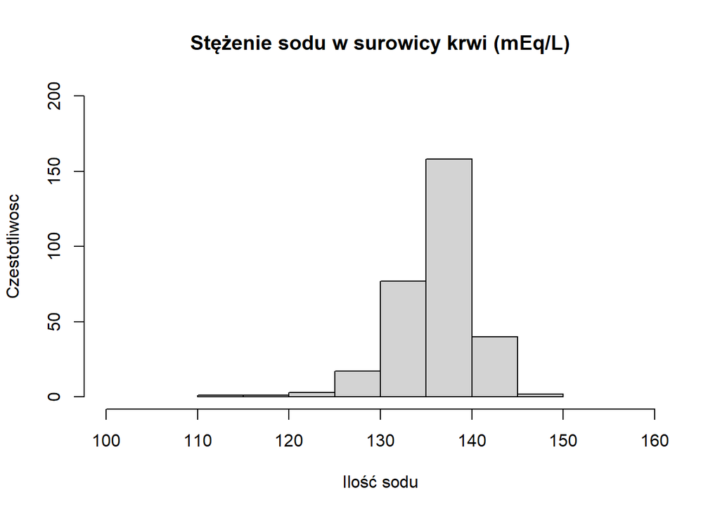

Kolejny wykres przedstawia stezenie sodu w surowicy krwi. Norma w tym przypadku wynosi 135-145 mEq/l. Jak mozna zauwazyc, rowniez okolo 80% wynikow miesci sie w przedziale 130-140 mEq/l. Pozostala czesc ma jej nadmiar, badz niedobor.

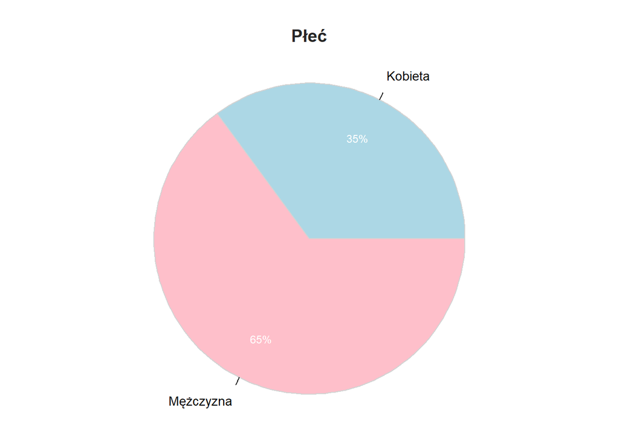

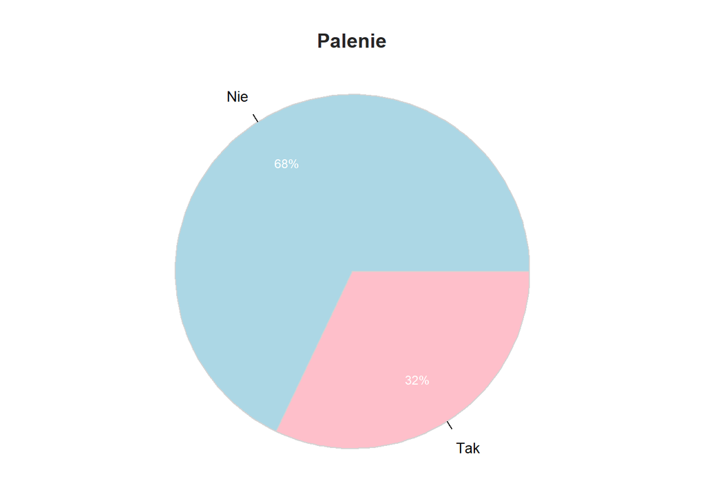

Ostatni wykres pokazuje, czy w zebranych danych znajduja sie osoby palace, czy tez nie. Jak i wiekszosci, tak i w tym przypadku dane nie rozkladaja sie rownomiernie. Osob palacych jest nieco mniej niz 1/3 wszystkich (32%), natomiast osoby nie palace stanowia 68%.

### Analiza wplywu poszczegolnych zmiennych na zmienną prognozowana Y

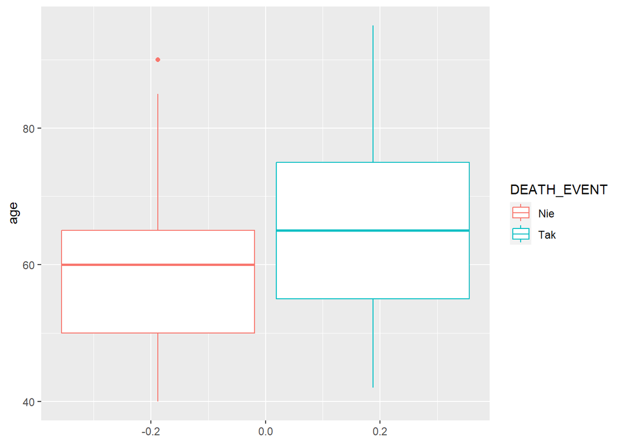

Rozklad jest lewostronnie skosny w grupie osob ktore przezyły i symetryczny w drugiej grupie. Mediana wieku osob zmarłych jest wyzsza,oraz zakres miedzy kwartylowy jest minimalnie wiekszy.

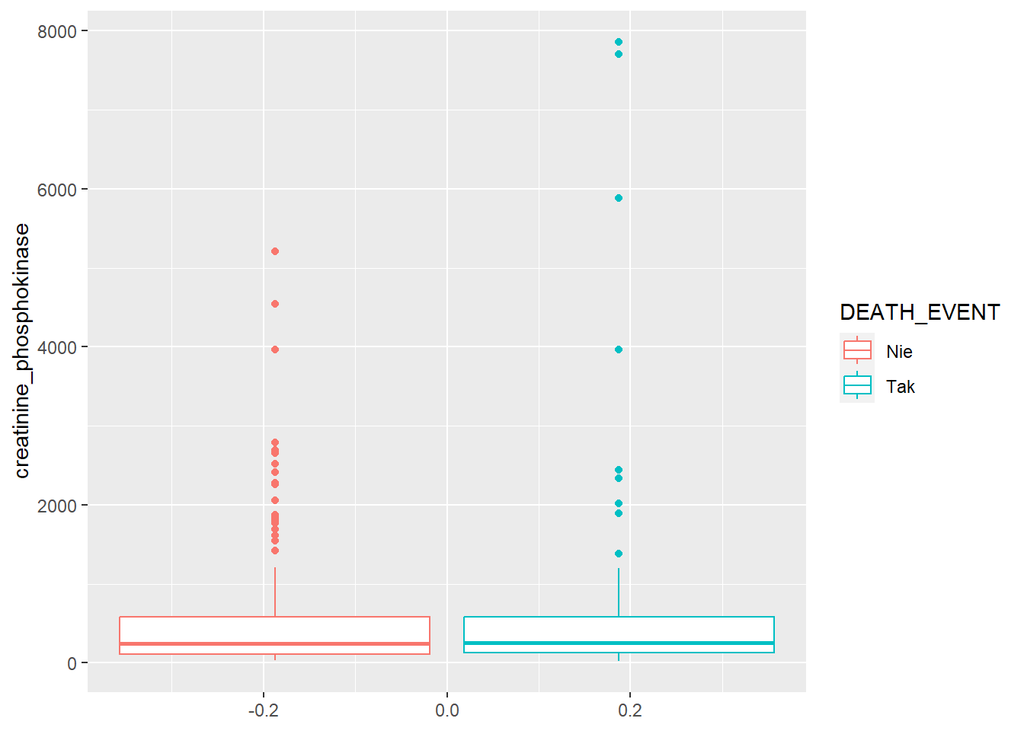

W obu grupach wykresy sa bardzo podobne. Wystepuje prawostronna skosnosc

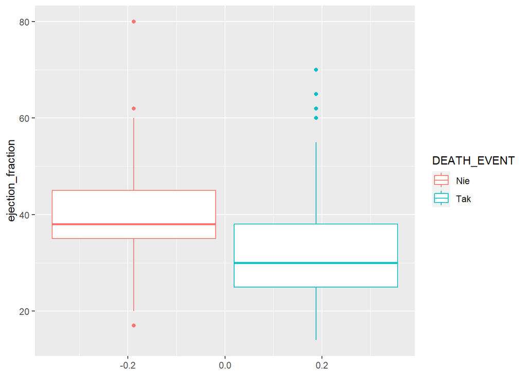

Mediana grupy osob ktore umarły znajduje sie niżej niz grupy oosb ktore przezyły, rozstep miedzykwartylowy jest podobny.

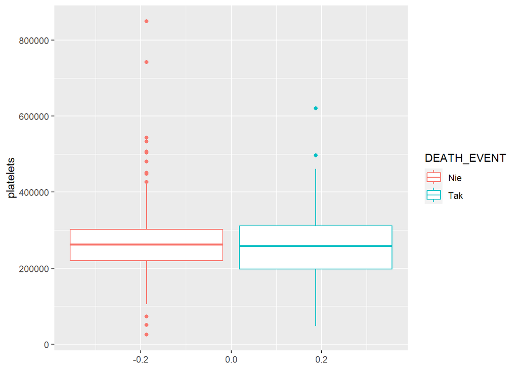

Rozklad symetryczny w obu grupach. Mediana na tym samym poziomi IQR wieksze w grupie osób ktore zmarły.

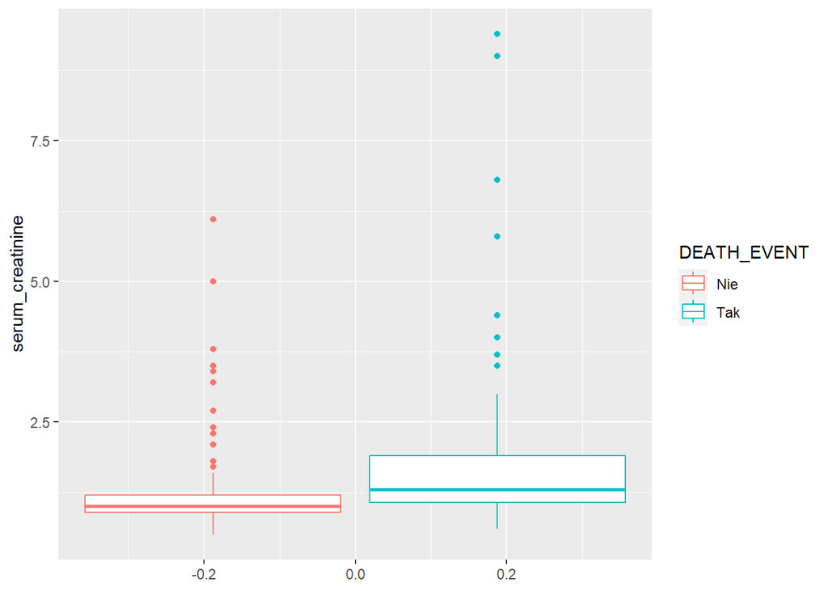

Rozklad prawostronnie skosny w obu grupach. Duzo mnniejsze IQR w grupie osob które przezyły

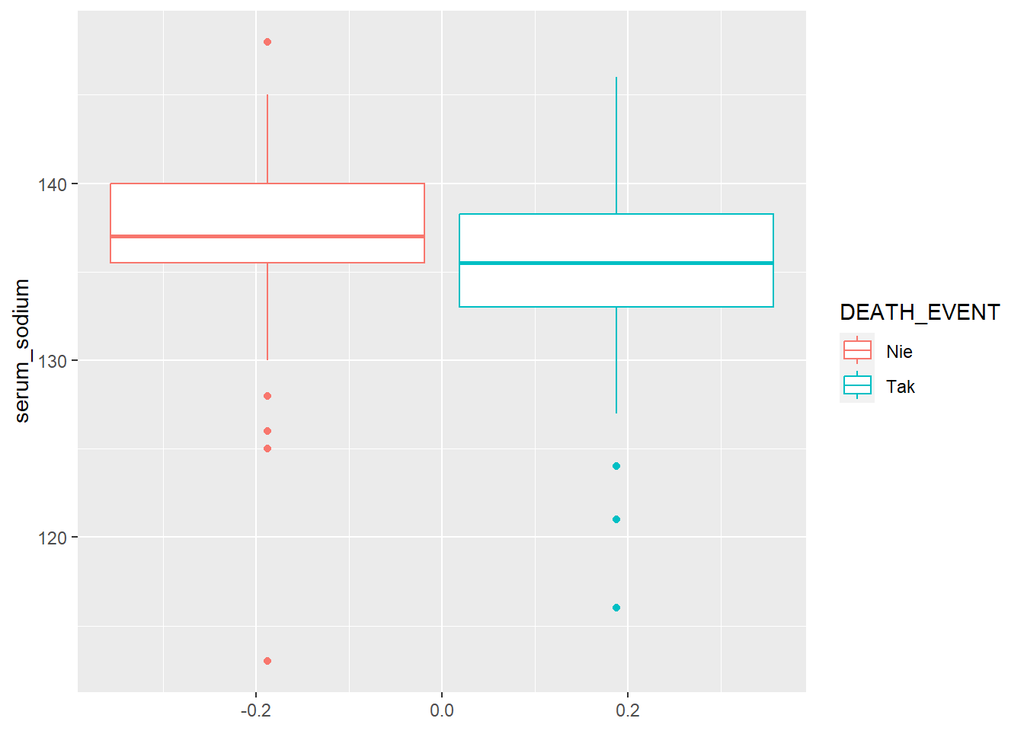

W grupie osob ktore przezyły rozklad prawostronnie skosny w drugiej grupie symetryczny. Podobne IQR

## 1) Metoda KNN

Pierwsza wykorzystana w pracy metoda jest KNN (k nearest neighbours). Tlumaczac na polski, jest to metoda k najblizszych sasiadow, ktora polega (jak sama nazwa wskazuje) na wyznaczeniu k najblizszych obiektow, ktore maja najmniejsza odleglosc wedlug pewnej metryki. Algorytm knn znajduje podobienstwo miedzy zminnymi (czyli zaklada, ze im blizej siebie znajduje sie dane punkty, tym sa bardziej do siebie podobne)

W pierwszym kroku załadowano dane. (Z danych w przypadku wszystkich metod zostala usunieta zmienna time). Nastepnie ustawiono seed’a na 59 oraz wyznaczono dwa zbiory danych: * zbior uczacy, ktory obejmuje okolo 80% danych * zbior testowy, pozostale 20% danych, na ktorych bedzie oceniana jakosc uzyskanej prognozy

Po wylosowaniu zbiorow zarowno uczacego, jak i testowego, sprawdzono statystyki dla obydwu zbiorow. Jak mozna zauwazyc ponizej, statystyki nie roznia sie znaczaco, srednia kazdej zmiennej jest na podobnym poziomie, jak i inne wartosci np. max czy min.

|  | age | anaemia | creatinine_phosphokinase | diabetes | ejection_fraction | high_blood_pressure | platelets | serum_creatinine | serum_sodium | sex | smoking | DEATH_EVENT |
| --- | --- | --- | --- | --- | --- | --- | --- | --- | --- | --- | --- | --- |
|  | Min. :40.0 | Min. :0.0000 | Min. : 23.0 | Min. :0.0000 | Min. :14.00 | Min. :0.0000 | Min. : 25100 | Min. :0.500 | Min. :113.0 | Min. :0.0000 | Min. :0.0000 | Min. :0.0000 |
|  | 1st Qu.:51.0 | 1st Qu.:0.0000 | 1st Qu.: 114.0 | 1st Qu.:0.0000 | 1st Qu.:30.00 | 1st Qu.:0.0000 | 1st Qu.:217000 | 1st Qu.:0.900 | 1st Qu.:134.0 | 1st Qu.:0.0000 | 1st Qu.:0.0000 | 1st Qu.:0.0000 |
|  | Median :60.0 | Median :0.0000 | Median : 245.0 | Median :0.0000 | Median :38.00 | Median :0.0000 | Median :262000 | Median :1.100 | Median :137.0 | Median :1.0000 | Median :0.0000 | Median :0.0000 |
|  | Mean :61.2 | Mean :0.4351 | Mean : 563.8 | Mean :0.4226 | Mean :38.21 | Mean :0.3347 | Mean :264585 | Mean :1.383 | Mean :136.7 | Mean :0.6318 | Mean :0.3096 | Mean :0.2929 |
|  | 3rd Qu.:70.0 | 3rd Qu.:1.0000 | 3rd Qu.: 582.0 | 3rd Qu.:1.0000 | 3rd Qu.:45.00 | 3rd Qu.:1.0000 | 3rd Qu.:304000 | 3rd Qu.:1.400 | 3rd Qu.:140.0 | 3rd Qu.:1.0000 | 3rd Qu.:1.0000 | 3rd Qu.:1.0000 |
|  | Max. :95.0 | Max. :1.0000 | Max. :7861.0 | Max. :1.0000 | Max. :80.00 | Max. :1.0000 | Max. :850000 | Max. :9.400 | Max. :148.0 | Max. :1.0000 | Max. :1.0000 | Max. :1.0000 |

|  | age | anaemia | creatinine_phosphokinase | diabetes | ejection_fraction | high_blood_pressure | platelets | serum_creatinine | serum_sodium | sex | smoking | DEATH_EVENT |
| --- | --- | --- | --- | --- | --- | --- | --- | --- | --- | --- | --- | --- |
|  | Min. :40.00 | Min. :0.0000 | Min. : 47.0 | Min. :0.0 | Min. :20.00 | Min. :0.0000 | Min. : 62000 | Min. :0.600 | Min. :127.0 | Min. :0.0000 | Min. :0.0000 | Min. :0.0000 |
|  | 1st Qu.:50.00 | 1st Qu.:0.0000 | 1st Qu.: 127.8 | 1st Qu.:0.0 | 1st Qu.:30.00 | 1st Qu.:0.0000 | 1st Qu.:208250 | 1st Qu.:1.000 | 1st Qu.:134.0 | 1st Qu.:0.0000 | 1st Qu.:0.0000 | 1st Qu.:0.0000 |
|  | Median :60.00 | Median :0.0000 | Median : 331.0 | Median :0.0 | Median :38.00 | Median :0.0000 | Median :262500 | Median :1.180 | Median :136.0 | Median :1.0000 | Median :0.0000 | Median :0.0000 |
|  | Mean :59.39 | Mean :0.4167 | Mean : 653.7 | Mean :0.4 | Mean :37.57 | Mean :0.4167 | Mean :258469 | Mean :1.436 | Mean :136.2 | Mean :0.7167 | Mean :0.3667 | Mean :0.4333 |
|  | 3rd Qu.:65.25 | 3rd Qu.:1.0000 | 3rd Qu.: 582.0 | 3rd Qu.:1.0 | 3rd Qu.:45.00 | 3rd Qu.:1.0000 | 3rd Qu.:302500 | 3rd Qu.:1.425 | 3rd Qu.:139.0 | 3rd Qu.:1.0000 | 3rd Qu.:1.0000 | 3rd Qu.:1.0000 |
|  | Max. :85.00 | Max. :1.0000 | Max. :7702.0 | Max. :1.0 | Max. :70.00 | Max. :1.0000 | Max. :481000 | Max. :9.000 | Max. :144.0 | Max. :1.0000 | Max. :1.0000 | Max. :1.0000 |

Nastepnie sprawdzono dane pod katem zbilansowania. Jak mozna zobaczyc, dane nie rozkladaja sie rownomiernie, nie sa zbilansowane. Dlatego tez w ocenie prognozy wieksza uwage przykuto do czulosci ‘sensitivity’ niz dokladnosci ‘accuracy’.

```r
# Dane nie są zbilansowane - patrzymy na czułość
summary(as.factor(dataKNN$DEATH_EVENT))
```

```
##   0   1
## 203  96
```

W kolejnym kroku zestandaryzowano zbiory (uczacy i testowy) oraz przystapiono do wyboru liczby k-najblizszych sasiadow. Za pomoca petli for() szukano k (nieparzystych) dla zbioru uczacego.

```
##
## knn_uczacy   0   1
##          0 153  33
##          1  16  37
## Dokladnosc dla  3  sasiadow: 0.7949791
## Czulosc dla 3  sasiadow: 0.5285714
## Specyficznosc dla 3  sasiadow: 0.9053254
##
## knn_uczacy   0   1
##          0 158  39
##          1  11  31
## Dokladnosc dla  5  sasiadow: 0.790795
## Czulosc dla 5  sasiadow: 0.4428571
## Specyficznosc dla 5  sasiadow: 0.9349112
##
## knn_uczacy   0   1
##          0 157  42
##          1  12  28
## Dokladnosc dla  7  sasiadow: 0.7740586
## Czulosc dla 7  sasiadow: 0.4
## Specyficznosc dla 7  sasiadow: 0.9289941
##
## knn_uczacy   0   1
##          0 158  46
##          1  11  24
## Dokladnosc dla  9  sasiadow: 0.7615063
## Czulosc dla 9  sasiadow: 0.3428571
## Specyficznosc dla 9  sasiadow: 0.9349112
##
## knn_uczacy   0   1
##          0 160  40
##          1   9  30
## Dokladnosc dla  11  sasiadow: 0.7949791
## Czulosc dla 11  sasiadow: 0.4285714
## Specyficznosc dla 11  sasiadow: 0.9467456
##
## knn_uczacy   0   1
##          0 159  45
##          1  10  25
## Dokladnosc dla  13  sasiadow: 0.7698745
## Czulosc dla 13  sasiadow: 0.3571429
## Specyficznosc dla 13  sasiadow: 0.9408284
##
## knn_uczacy   0   1
##          0 160  47
##          1   9  23
## Dokladnosc dla  15  sasiadow: 0.7656904
## Czulosc dla 15  sasiadow: 0.3285714
## Specyficznosc dla 15  sasiadow: 0.9467456
##
## knn_uczacy   0   1
##          0 160  48
##          1   9  22
## Dokladnosc dla  17  sasiadow: 0.7615063
## Czulosc dla 17  sasiadow: 0.3142857
## Specyficznosc dla 17  sasiadow: 0.9467456
```

Wygenerowano macierze bledow dla osmiu wartosci k, na podstawie ktorych obliczono miary jakosci modelu tj. dokladnosc, czulosc oraz specyficznosc. Jak wspomniano wyzej, ze wzgledu na niezbilansowane dane, uwage skupiono na czulosci. Jest to miara zasięgu, która bada, w jakiej części klasa pozytywna została pokryta przewidywaniem pozytywnym.

Najwyzsza czulosc zanotowano dla k=3 i wynosi ona 0.53 przy specyficznosci 0.91. Do k=9 czulosc maleje, a potem w k=11 na moment wzrasta do 0.43.

Nastepnie analogicznie jak wyzej, sprawdzano k dla zbioru testowego.

```
##
## knn_testowy  0  1
##           0 31 17
##           1  3  9
## Dokladnosc dla  3  sasiadow: 0.6666667
## Czulosc dla 3  sasiadow: 0.3461538
## Specyficznosc dla 3  sasiadow: 0.9117647
##
## knn_testowy  0  1
##           0 31 20
##           1  3  6
## Dokladnosc dla  5  sasiadow: 0.6166667
## Czulosc dla 5  sasiadow: 0.2307692
## Specyficznosc dla 5  sasiadow: 0.9117647
##
## knn_testowy  0  1
##           0 32 18
##           1  2  8
## Dokladnosc dla  7  sasiadow: 0.6666667
## Czulosc dla 7  sasiadow: 0.3076923
## Specyficznosc dla 7  sasiadow: 0.9411765
##
## knn_testowy  0  1
##           0 33 19
##           1  1  7
## Dokladnosc dla  9  sasiadow: 0.6666667
## Czulosc dla 9  sasiadow: 0.2692308
## Specyficznosc dla 9  sasiadow: 0.9705882
##
## knn_testowy  0  1
##           0 33 20
##           1  1  6
## Dokladnosc dla  11  sasiadow: 0.65
## Czulosc dla 11  sasiadow: 0.2307692
## Specyficznosc dla 11  sasiadow: 0.9705882
##
## knn_testowy  0  1
##           0 33 20
##           1  1  6
## Dokladnosc dla  13  sasiadow: 0.65
## Czulosc dla 13  sasiadow: 0.2307692
## Specyficznosc dla 13  sasiadow: 0.9705882
##
## knn_testowy  0  1
##           0 33 21
##           1  1  5
## Dokladnosc dla  15  sasiadow: 0.6333333
## Czulosc dla 15  sasiadow: 0.1923077
## Specyficznosc dla 15  sasiadow: 0.9705882
##
## knn_testowy  0  1
##           0 34 22
##           1  0  4
## Dokladnosc dla  17  sasiadow: 0.6333333
## Czulosc dla 17  sasiadow: 0.1538462
## Specyficznosc dla 17  sasiadow: 1
```

Jak latwo zauwazyc w przypadku zbioru testowego wartosci dokladnosci czy czulosci sa nieco nizsze, ale analogicznie jak w przypadku zbioru uczacego najwyzsza czulosc wypada w przypadku k=3 i wynosi 0.35. Zarowno w przypadku szukania k dla zbioru uczacego i tetowego specyficznosc jest wysoka, oscyluje w okolicach 0.9. Specyficzność jest miara zasięgu pokazująca, w jakiej części klasa negatywna jest pokryta prognozą negatywną.

Dlatego tez sprawdzono metoda knn macierz bledu i krzywa ROC dla k = 3.

```
##
## knn_ucz   0   1
##       0 153  33
##       1  16  37
```

```
##
## knn_tes  0  1
##       0 31 17
##       1  3  9
```

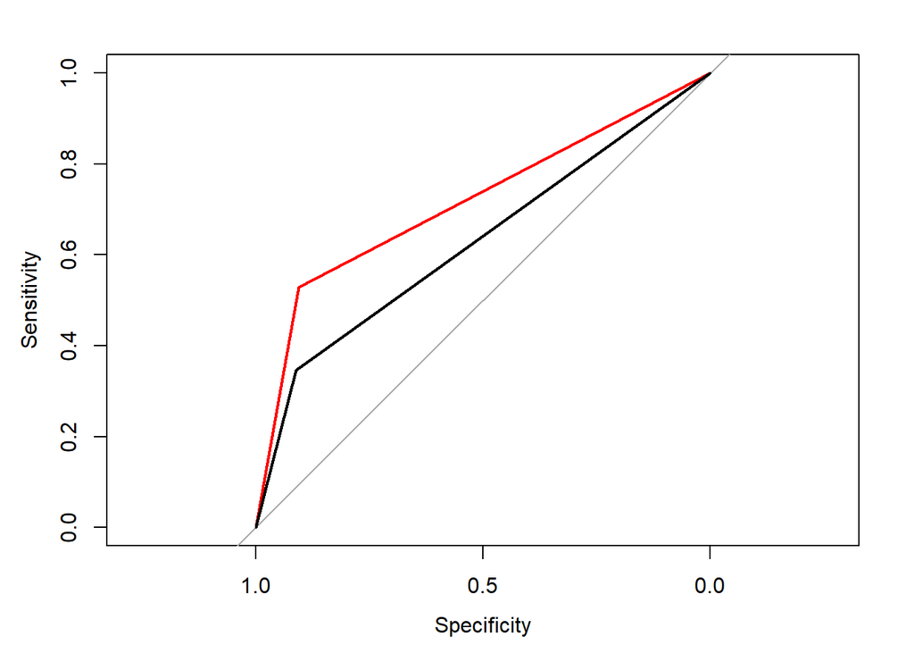

```
## Area under the curve: 0.7169
```

```
## Area under the curve: 0.629
```

Powyzej wygenerowano krzywe ROC. Krzywa ROC opisuje zachowanie modelu dla różnych punktów odcięcia. Na osi X są różne poziomy 1 – specyficzności, a na osi Y różne poziomy czułości. Model jest tym lepszy im bardziej krzywa ROC unosi się nad krzywą y = x. Na podstawie krzywej ROC możemy wybrać rozsądny, z naszego punktu widzenia, punkt odcięcia.

W tym przypadku pola AUC po krzywa ROC maja w miare zadowalajacy wynik: 0.72 i 0.63.

## 2) Regresja logistyczna

```
##       age           anaemia       creatinine_phosphokinase    diabetes
##  Min.   :40.00   Min.   :0.0000   Min.   :  23.0           Min.   :0.0000
##  1st Qu.:51.00   1st Qu.:0.0000   1st Qu.: 116.5           1st Qu.:0.0000
##  Median :60.00   Median :0.0000   Median : 250.0           Median :0.0000
##  Mean   :60.83   Mean   :0.4314   Mean   : 581.8           Mean   :0.4181
##  3rd Qu.:70.00   3rd Qu.:1.0000   3rd Qu.: 582.0           3rd Qu.:1.0000
##  Max.   :95.00   Max.   :1.0000   Max.   :7861.0           Max.   :1.0000
##  ejection_fraction high_blood_pressure   platelets      serum_creatinine
##  Min.   :14.00     Min.   :0.0000      Min.   : 25100   Min.   :0.500
##  1st Qu.:30.00     1st Qu.:0.0000      1st Qu.:212500   1st Qu.:0.900
##  Median :38.00     Median :0.0000      Median :262000   Median :1.100
##  Mean   :38.08     Mean   :0.3512      Mean   :263358   Mean   :1.394
##  3rd Qu.:45.00     3rd Qu.:1.0000      3rd Qu.:303500   3rd Qu.:1.400
##  Max.   :80.00     Max.   :1.0000      Max.   :850000   Max.   :9.400
##   serum_sodium        sex            smoking        DEATH_EVENT
##  Min.   :113.0   Min.   :0.0000   Min.   :0.0000   Min.   :0.0000
##  1st Qu.:134.0   1st Qu.:0.0000   1st Qu.:0.0000   1st Qu.:0.0000
##  Median :137.0   Median :1.0000   Median :0.0000   Median :0.0000
##  Mean   :136.6   Mean   :0.6488   Mean   :0.3211   Mean   :0.3211
##  3rd Qu.:140.0   3rd Qu.:1.0000   3rd Qu.:1.0000   3rd Qu.:1.0000
##  Max.   :148.0   Max.   :1.0000   Max.   :1.0000   Max.   :1.0000
```

```
##
## Call:
## glm(formula = DEATH_EVENT ~ ., family = "binomial", data = zb_uczacy)
##
## Deviance Residuals:
##     Min       1Q   Median       3Q      Max
## -2.0283  -0.7456  -0.4234   0.7670   2.5624
##
## Coefficients:
##                              Estimate   Std. Error z value  Pr(>|z|)
## (Intercept)               4.216176662  4.963622060   0.849   0.39565
## age                       0.068292876  0.015187348   4.497 0.0000069 ***
## anaemia                   0.473995372  0.345782551   1.371   0.17044
## creatinine_phosphokinase  0.000278354  0.000176044   1.581   0.11384
## diabetes                  0.078193214  0.341825155   0.229   0.81906
## ejection_fraction        -0.069617787  0.017446642  -3.990 0.0000660 ***
## high_blood_pressure       0.293429616  0.361364894   0.812   0.41679
## platelets                -0.000001893  0.000001870  -1.013   0.31128
## serum_creatinine          0.503514145  0.182294360   2.762   0.00574 **
## serum_sodium             -0.054454268  0.035875792  -1.518   0.12905
## sex                      -0.138200551  0.399411953  -0.346   0.72934
## smoking                  -0.336652977  0.409392584  -0.822   0.41089
## ---
## Signif. codes:  0 '***' 0.001 '**' 0.01 '*' 0.05 '.' 0.1 ' ' 1
##
## (Dispersion parameter for binomial family taken to be 1)
##
##     Null deviance: 289.05  on 238  degrees of freedom
## Residual deviance: 223.58  on 227  degrees of freedom
## AIC: 247.58
##
## Number of Fisher Scoring iterations: 5
```

```
##
## Call:
## glm(formula = DEATH_EVENT ~ . - anaemia - creatinine_phosphokinase -
##     diabetes - high_blood_pressure - platelets - serum_sodium -
##     sex - smoking, family = "binomial", data = zb_uczacy)
##
## Deviance Residuals:
##     Min       1Q   Median       3Q      Max
## -2.0341  -0.7394  -0.4624   0.8207   2.4168
##
## Coefficients:
##                   Estimate Std. Error z value   Pr(>|z|)
## (Intercept)       -3.27269    0.97232  -3.366   0.000763 ***
## age                0.06530    0.01426   4.581 0.00000464 ***
## ejection_fraction -0.06796    0.01632  -4.164 0.00003131 ***
## serum_creatinine   0.53219    0.17283   3.079   0.002075 **
## ---
## Signif. codes:  0 '***' 0.001 '**' 0.01 '*' 0.05 '.' 0.1 ' ' 1
##
## (Dispersion parameter for binomial family taken to be 1)
##
##     Null deviance: 289.05  on 238  degrees of freedom
## Residual deviance: 231.88  on 235  degrees of freedom
## AIC: 239.88
##
## Number of Fisher Scoring iterations: 5
```

```
##
## prog_train   0   1
##          0  14  34
##          1 155  36
## Dokladnosc dla  0.5  progu odciecia: 0.209205
## Czulosc dla 0.5  progu odciecia: 0.5142857
## Specyficznosc dla 0.5  progu odciecia: 0.08284024
##
## prog_train   0   1
##          0   8  22
##          1 161  48
## Dokladnosc dla  0.6  progu odciecia: 0.2343096
## Czulosc dla 0.6  progu odciecia: 0.6857143
## Specyficznosc dla 0.6  progu odciecia: 0.04733728
##
## prog_train   0   1
##          0   1  10
##          1 168  60
## Dokladnosc dla  0.7  progu odciecia: 0.2552301
## Czulosc dla 0.7  progu odciecia: 0.8571429
## Specyficznosc dla 0.7  progu odciecia: 0.00591716
```

```
##
## prog_test  0  1
##         0  1  7
##         1 33 19
## Dokladnosc dla  0.5  progu odciecia: 0.3333333
## Czulosc dla 0.5  progu odciecia: 0.7307692
## Specyficznosc dla 0.5  progu odciecia: 0.02941176
##
## prog_test  0  1
##         0  1  3
##         1 33 23
## Dokladnosc dla  0.6  progu odciecia: 0.4
## Czulosc dla 0.6  progu odciecia: 0.8846154
## Specyficznosc dla 0.6  progu odciecia: 0.02941176
##
## prog_test  0  1
##         0  0  2
##         1 34 24
## Dokladnosc dla  0.7  progu odciecia: 0.4
## Czulosc dla 0.7  progu odciecia: 0.9230769
## Specyficznosc dla 0.7  progu odciecia: 0
```

## 3) Klasyfikator Naiwny Bayesa

```r
# załadowanie danych
dataBayes <- read.csv('heart_failure_clinical_records_dataset.csv')
dataBayes$time <- NULL
```

```r
#sprawdzenie rozkladu normlanego dla kazdej kolumny
dataBayes1 <- dataBayes[dataBayes$DEATH_EVENT == "1",-12]
dataBayes0 <- dataBayes[dataBayes$DEATH_EVENT == "0",-12]
rozklad1 <- lapply(dataBayes1,shapiro.test)
rozklad0 <- lapply(dataBayes0,shapiro.test)
lrozklad1 <- sapply(rozklad1, `[`, c("statistic","p.value"))
lrozklad0 <- sapply(rozklad0, `[`, c("statistic","p.value"))
```

```r
#sprawdzenie podstawowych statystyk opisowych w grupach
describe(dataBayes1)
```

```
##                          vars  n      mean       sd   median   trimmed      mad
## age                         1 96     65.22    13.21     65.0     64.71    14.83
## anaemia                     2 96      0.48     0.50      0.0      0.47     0.00
## creatinine_phosphokinase    3 96    670.20  1316.58    259.0    363.47   256.49
## diabetes                    4 96      0.42     0.50      0.0      0.40     0.00
## ejection_fraction           5 96     33.47    12.53     30.0     32.18    11.86
## high_blood_pressure         6 96      0.41     0.49      0.0      0.38     0.00
## platelets                   7 96 256381.04 98525.68 258500.0 252404.88 88214.70
## serum_creatinine            8 96      1.84     1.47      1.3      1.53     0.59
## serum_sodium                9 96    135.38     5.00    135.5    135.55     3.71
## sex                        10 96      0.65     0.48      1.0      0.68     0.00
## smoking                    11 96      0.31     0.47      0.0      0.27     0.00
##                              min      max    range  skew kurtosis       se
## age                         42.0     95.0     53.0  0.29    -0.71     1.35
## anaemia                      0.0      1.0      1.0  0.08    -2.01     0.05
## creatinine_phosphokinase    23.0   7861.0   7838.0  4.13    17.81   134.37
## diabetes                     0.0      1.0      1.0  0.33    -1.91     0.05
## ejection_fraction           14.0     70.0     56.0  0.80     0.07     1.28
## high_blood_pressure          0.0      1.0      1.0  0.38    -1.88     0.05
## platelets                47000.0 621000.0 574000.0  0.61     1.15 10055.74
## serum_creatinine             0.6      9.4      8.8  3.30    12.40     0.15
## serum_sodium               116.0    146.0     30.0 -0.66     1.81     0.51
## sex                          0.0      1.0      1.0 -0.60    -1.66     0.05
## smoking                      0.0      1.0      1.0  0.80    -1.38     0.05
```

```r
describe(dataBayes0)
```

```
##                          vars   n      mean       sd median   trimmed      mad
## age                         1 203     58.76    10.64     60     58.44    11.86
## anaemia                     2 203      0.41     0.49      0      0.39     0.00
## creatinine_phosphokinase    3 203    540.05   753.80    245    366.39   268.35
## diabetes                    4 203      0.42     0.49      0      0.40     0.00
## ejection_fraction           5 203     40.27    10.86     38     39.69    10.38
## high_blood_pressure         6 203      0.33     0.47      0      0.28     0.00
## platelets                   7 203 266657.49 97531.20 263000 258707.79 62269.20
## serum_creatinine            8 203      1.18     0.65      1      1.06     0.30
## serum_sodium                9 203    137.22     3.98    137    137.36     2.97
## sex                        10 203      0.65     0.48      1      0.69     0.00
## smoking                    11 203      0.33     0.47      0      0.28     0.00
##                              min      max    range  skew kurtosis      se
## age                         40.0     90.0     50.0  0.26    -0.39    0.75
## anaemia                      0.0      1.0      1.0  0.37    -1.87    0.03
## creatinine_phosphokinase    30.0   5209.0   5179.0  3.15    12.41   52.91
## diabetes                     0.0      1.0      1.0  0.33    -1.90    0.03
## ejection_fraction           17.0     80.0     63.0  0.69     0.16    0.76
## high_blood_pressure          0.0      1.0      1.0  0.74    -1.46    0.03
## platelets                25100.0 850000.0 824900.0  1.86     8.21 6845.35
## serum_creatinine             0.5      6.1      5.6  4.11    22.08    0.05
## serum_sodium               113.0    148.0     35.0 -1.20     6.21    0.28
## sex                          0.0      1.0      1.0 -0.63    -1.62    0.03
## smoking                      0.0      1.0      1.0  0.74    -1.46    0.03
```

Zamieniamy dane z ilosciowych na kategoryczne, za pomoca funkcji discretize i uzywamy metody “interval” zeby dane miały rowne szerokosci przedziałow.

```r
dataBayes$age <- discretize(dataBayes$age, method = "interval", breaks = 2)
dataBayes$creatinine_phosphokinase <- discretize(dataBayes$creatinine_phosphokinase, method = "interval", breaks = 2)
dataBayes$ejection_fraction <- discretize(dataBayes$ejection_fraction, method = "interval", breaks = 2)
dataBayes$platelets <- discretize(dataBayes$platelets, method = "interval", breaks = 2)
dataBayes$serum_creatinine <- discretize(dataBayes$serum_creatinine, method = "interval", breaks = 2)
dataBayes$serum_sodium <- discretize(dataBayes$serum_sodium, method = "interval", breaks = 2)
summary(dataBayes)
```

```
##         age         anaemia              creatinine_phosphokinase
##  [40,67.5):214   Min.   :0.0000   [23,3.94e+03)      :292
##  [67.5,95]: 85   1st Qu.:0.0000   [3.94e+03,7.86e+03]:  7
##                  Median :0.0000
##                  Mean   :0.4314
##                  3rd Qu.:1.0000
##                  Max.   :1.0000
##     diabetes      ejection_fraction high_blood_pressure
##  Min.   :0.0000   [14,47):239       Min.   :0.0000
##  1st Qu.:0.0000   [47,80]: 60       1st Qu.:0.0000
##  Median :0.0000                     Median :0.0000
##  Mean   :0.4181                     Mean   :0.3512
##  3rd Qu.:1.0000                     3rd Qu.:1.0000
##  Max.   :1.0000                     Max.   :1.0000
##                platelets     serum_creatinine    serum_sodium      sex
##  [2.51e+04,4.38e+05):285   [0.5,4.95):293     [113,130): 22   Min.   :0.0000
##  [4.38e+05,8.5e+05] : 14   [4.95,9.4]:  6     [130,148]:277   1st Qu.:0.0000
##                                                               Median :1.0000
##                                                               Mean   :0.6488
##                                                               3rd Qu.:1.0000
##                                                               Max.   :1.0000
##     smoking        DEATH_EVENT
##  Min.   :0.0000   Min.   :0.0000
##  1st Qu.:0.0000   1st Qu.:0.0000
##  Median :0.0000   Median :0.0000
##  Mean   :0.3211   Mean   :0.3211
##  3rd Qu.:1.0000   3rd Qu.:1.0000
##  Max.   :1.0000   Max.   :1.0000
```

Dzielimy dane na zbior uczacy i testowy

```r
set.seed(59)
sample <- sample(299, 239, replace = F)
zb_uczacy <- dataBayes[sample,]  # 70-80% danych
zb_testowy <- dataBayes[-sample,]   # oceniamy jakość uzyskanej prognozy
summary(zb_uczacy)
```

```
##         age         anaemia              creatinine_phosphokinase
##  [40,67.5):168   Min.   :0.0000   [23,3.94e+03)      :234
##  [67.5,95]: 71   1st Qu.:0.0000   [3.94e+03,7.86e+03]:  5
##                  Median :0.0000
##                  Mean   :0.4351
##                  3rd Qu.:1.0000
##                  Max.   :1.0000
##     diabetes      ejection_fraction high_blood_pressure
##  Min.   :0.0000   [14,47):189       Min.   :0.0000
##  1st Qu.:0.0000   [47,80]: 50       1st Qu.:0.0000
##  Median :0.0000                     Median :0.0000
##  Mean   :0.4226                     Mean   :0.3347
##  3rd Qu.:1.0000                     3rd Qu.:1.0000
##  Max.   :1.0000                     Max.   :1.0000
##                platelets     serum_creatinine    serum_sodium      sex
##  [2.51e+04,4.38e+05):228   [0.5,4.95):234     [113,130): 18   Min.   :0.0000
##  [4.38e+05,8.5e+05] : 11   [4.95,9.4]:  5     [130,148]:221   1st Qu.:0.0000
##                                                               Median :1.0000
##                                                               Mean   :0.6318
##                                                               3rd Qu.:1.0000
##                                                               Max.   :1.0000
##     smoking        DEATH_EVENT
##  Min.   :0.0000   Min.   :0.0000
##  1st Qu.:0.0000   1st Qu.:0.0000
##  Median :0.0000   Median :0.0000
##  Mean   :0.3096   Mean   :0.2929
##  3rd Qu.:1.0000   3rd Qu.:1.0000
##  Max.   :1.0000   Max.   :1.0000
```

```r
summary(zb_testowy)
```

```
##         age        anaemia              creatinine_phosphokinase    diabetes
##  [40,67.5):46   Min.   :0.0000   [23,3.94e+03)      :58          Min.   :0.0
##  [67.5,95]:14   1st Qu.:0.0000   [3.94e+03,7.86e+03]: 2          1st Qu.:0.0
##                 Median :0.0000                                   Median :0.0
##                 Mean   :0.4167                                   Mean   :0.4
##                 3rd Qu.:1.0000                                   3rd Qu.:1.0
##                 Max.   :1.0000                                   Max.   :1.0
##  ejection_fraction high_blood_pressure               platelets
##  [14,47):50        Min.   :0.0000      [2.51e+04,4.38e+05):57
##  [47,80]:10        1st Qu.:0.0000      [4.38e+05,8.5e+05] : 3
##                    Median :0.0000
##                    Mean   :0.4167
##                    3rd Qu.:1.0000
##                    Max.   :1.0000
##    serum_creatinine    serum_sodium      sex            smoking
##  [0.5,4.95):59      [113,130): 4    Min.   :0.0000   Min.   :0.0000
##  [4.95,9.4]: 1      [130,148]:56    1st Qu.:0.0000   1st Qu.:0.0000
##                                     Median :1.0000   Median :0.0000
##                                     Mean   :0.7167   Mean   :0.3667
##                                     3rd Qu.:1.0000   3rd Qu.:1.0000
##                                     Max.   :1.0000   Max.   :1.0000
##   DEATH_EVENT
##  Min.   :0.0000
##  1st Qu.:0.0000
##  Median :0.0000
##  Mean   :0.4333
##  3rd Qu.:1.0000
##  Max.   :1.0000
```

```r
#klasyfikator naiwany

nb_method <- naiveBayes(DEATH_EVENT~.,
                 data= zb_uczacy)

nb_method
```

```
##
## Naive Bayes Classifier for Discrete Predictors
##
## Call:
## naiveBayes.default(x = X, y = Y, laplace = laplace)
##
## A-priori probabilities:
## Y
##        0        1
## 0.707113 0.292887
##
## Conditional probabilities:
##    age
## Y   [40,67.5) [67.5,95]
##   0 0.7869822 0.2130178
##   1 0.5000000 0.5000000
##
##    anaemia
## Y        [,1]      [,2]
##   0 0.4023669 0.4918324
##   1 0.5142857 0.5034046
##
##    creatinine_phosphokinase
## Y   [23,3.94e+03) [3.94e+03,7.86e+03]
##   0    0.98224852          0.01775148
##   1    0.97142857          0.02857143
##
##    diabetes
## Y        [,1]      [,2]
##   0 0.4260355 0.4959685
##   1 0.4142857 0.4961550
##
##    ejection_fraction
## Y     [14,47)   [47,80]
##   0 0.7692308 0.2307692
##   1 0.8428571 0.1571429
##
##    high_blood_pressure
## Y        [,1]      [,2]
##   0 0.3195266 0.4676789
```

[output cut: 11 more lines]

```
##
##    serum_sodium
## Y    [113,130)  [130,148]
##   0 0.05325444 0.94674556
##   1 0.12857143 0.87142857
##
##    sex
## Y        [,1]      [,2]
##   0 0.6213018 0.4865043
##   1 0.6571429 0.4780914
##
##    smoking
## Y        [,1]      [,2]
##   0 0.3254438 0.4699328
##   1 0.2714286 0.4479075
```

Robimy prognoze na zbiore uczacym. Generujemy macierz błedu do ocenienia naszej prognozy otrzymane wyniki:

```r
#prognoza na uczacym
nb_predict_uczacy <- predict(nb_method, zb_uczacy)

#macierz błedu
macierz_bledu_1 <- table(nb_predict_uczacy, zb_uczacy$DEATH_EVENT)
macierz_bledu_1
```

```
##
## nb_predict_uczacy   0   1
##                 0 159  54
##                 1  10  16
```

```r
dokl1 <- (macierz_bledu_1[2,2]+macierz_bledu_1[1,1])/(macierz_bledu_1[1,1]+macierz_bledu_1[1,2]+macierz_bledu_1[2,1]+macierz_bledu_1[2,2])
czul1 <- macierz_bledu_1[2,2]/(macierz_bledu_1[2,2]+macierz_bledu_1[1,2])
specyf1 <- macierz_bledu_1[1,1]/(macierz_bledu_1[1,1]+macierz_bledu_1[2,1])

cat("Dokladnosc na zb ucz: ", dokl1, '\n')
```

```
## Dokladnosc na zb ucz:  0.7322176
```

```r
cat("Czulosc na zb ucz: ", czul1, '\n')
```

```
## Czulosc na zb ucz:  0.2285714
```

```r
cat("Specyficznosc na zb ucz: ", specyf1, '\n')
```

```
## Specyficznosc na zb ucz:  0.9408284
```

Dokladnosc na zb ucz: 0.7322176 Czulosc na zb ucz: 0.2285714 Specyficznosc na zb ucz: 0.9408284

Nastepnie prognoza na zbiorze testowym

```r
#prognoza na testowym
nb_predict_testowy <- predict(nb_method, zb_testowy)

#Macierz bledu i dokladnosc
macierz_bledu_2 <- table(nb_predict_testowy, zb_testowy$DEATH_EVENT)
macierz_bledu_2
```

```
##
## nb_predict_testowy  0  1
##                  0 31 24
##                  1  3  2
```

```r
dokl2 <- (macierz_bledu_2[2,2]+macierz_bledu_2[1,1])/(macierz_bledu_2[1,1]+macierz_bledu_2[1,2]+macierz_bledu_2[2,1]+macierz_bledu_2[2,2])
czul2 <- macierz_bledu_2[2,2]/(macierz_bledu_2[2,2]+macierz_bledu_2[1,2])
specyf2 <- macierz_bledu_2[1,1]/(macierz_bledu_2[1,1]+macierz_bledu_2[2,1])

cat("Dokladnosc na zb tes: ", dokl2, '\n')
```

```
## Dokladnosc na zb tes:  0.55
```

```r
cat("Czulosc na zb tes: ", czul2, '\n')
```

```
## Czulosc na zb tes:  0.07692308
```

```r
cat("Specyficznosc na zb tes: ", specyf2, '\n')
```

```
## Specyficznosc na zb tes:  0.9117647
```

Otrzymana czułość na zbiorze testowym jest bardzo mała.

Kolejnym krokiem jest zmiana progu odciecia i porownanie wynikow:

```r
#zmiana progu odciecia na zbiorze uczacym
nb_predict_uczacy_2 <- predict(nb_method, zb_uczacy, type = "raw")

for(i in c(0.5, 0.6, 0.7))
{
  wyniki <- ifelse(nb_predict_uczacy_2[ ,1] > i, 0, 1) #prawdopodobienstwo tego ze not dead > i

  tab <- table(wyniki, zb_uczacy$DEATH_EVENT)
  print(tab)
  prog=i

  cat('Dokladnosc dla ', prog, ' progu odciecia:', (tab[2,2]+tab[1,1])/(tab[1,1]+tab[1,2]+tab[2,1]+tab[2,2]), '\n')
  cat('Czulosc dla', prog, ' progu odciecia:', tab[2,2]/(tab[2,2]+tab[1,2]), '\n')
  cat('Specyficznosc dla', prog, ' progu odciecia:', tab[1,1]/(tab[1,1]+tab[2,1]), '\n')
}
```

```
##
## wyniki   0   1
##      0 159  54
##      1  10  16
## Dokladnosc dla  0.5  progu odciecia: 0.7322176
## Czulosc dla 0.5  progu odciecia: 0.2285714
## Specyficznosc dla 0.5  progu odciecia: 0.9408284
##
## wyniki   0   1
##      0 139  33
##      1  30  37
## Dokladnosc dla  0.6  progu odciecia: 0.7364017
## Czulosc dla 0.6  progu odciecia: 0.5285714
## Specyficznosc dla 0.6  progu odciecia: 0.8224852
##
## wyniki   0   1
##      0 124  26
##      1  45  44
## Dokladnosc dla  0.7  progu odciecia: 0.7029289
## Czulosc dla 0.7  progu odciecia: 0.6285714
## Specyficznosc dla 0.7  progu odciecia: 0.7337278
```

Widzimy, że wraz ze wzrostem progu odciecia wzrasta nam czułość naszej prognozy. Przy progu odciecia 0,7 czułość osiagneła wartosc 0.6285714 co jest dużo lepszym wynikiem niz 0.2285714

```r
#zmiana progu odciecia na zbiorze testowym

nb_predict_testowy_2 <- predict(nb_method, zb_testowy, type = "raw")

for(i in c(0.5, 0.6, 0.7))
{
  wyniki <- ifelse(nb_predict_testowy_2[ ,1] > i, 0, 1) #prawdopodobienstwo tego ze not dead > i

  tab <- table(wyniki, zb_testowy$DEATH_EVENT)
  print(tab)
  prog=i

  cat('Dokladnosc dla ', prog, ' progu odciecia:', (tab[2,2]+tab[1,1])/(tab[1,1]+tab[1,2]+tab[2,1]+tab[2,2]), '\n')
  cat('Czulosc dla', prog, ' progu odciecia:', tab[2,2]/(tab[2,2]+tab[1,2]), '\n')
  cat('Specyficznosc dla', prog, ' progu odciecia:', tab[1,1]/(tab[1,1]+tab[2,1]), '\n')
}
```

```
##
## wyniki  0  1
##      0 31 24
##      1  3  2
## Dokladnosc dla  0.5  progu odciecia: 0.55
## Czulosc dla 0.5  progu odciecia: 0.07692308
## Specyficznosc dla 0.5  progu odciecia: 0.9117647
##
## wyniki  0  1
##      0 28 17
##      1  6  9
## Dokladnosc dla  0.6  progu odciecia: 0.6166667
## Czulosc dla 0.6  progu odciecia: 0.3461538
## Specyficznosc dla 0.6  progu odciecia: 0.8235294
##
## wyniki  0  1
##      0 26 15
##      1  8 11
## Dokladnosc dla  0.7  progu odciecia: 0.6166667
## Czulosc dla 0.7  progu odciecia: 0.4230769
## Specyficznosc dla 0.7  progu odciecia: 0.7647059
```

Ponownie najlpesze wyniki otrzymane sa dla poziomu odciecia 0.7. Przy takim poziomie odciecia jakosc naszej prognozy znacząco sie poprawiła ## 4) Metoda KKNN